# Assignment 6 DA5020

Victoria Liebsch-Aljawahiri

2022-10-26

## Preparations

Load required libraries and custom functions.

```r
# Libraries
library(DBI)
library(RSQLite)
library(tidyverse)
library(stringr)
library(skimr)
library(janitor)
library(scales)
library(readr)
library(glue)
library(viridis)

# Functions
# Theme for plot
cool_theme <- function() {
  theme_minimal() +
  theme(
    text = element_text(family = "Bookman", color = "gray25"),
    plot.subtitle = element_text(size = 12),
    plot.caption = element_text(color = "gray30"),
    plot.background = element_rect(fill = "gray95"),
    plot.margin = unit(c(5, 10, 5, 10), units = "mm")
  )
}
```

## Question 1

This question should be done completely in the SQLite Console, not in R. Start by loading the imdb.db file using the console and download the directors.csv file.

#### 1. Create a table named `director_info` using SQLite; the columns are: `Director_ID`, and

#### `Director_Name`. The `Director_ID` should be the primary key.

```sql
/* Enter SQLite in terminal */
sqlite3

/* Load file */
.open "Desktop/DA5020/Assignment_6/imdb.db"

/* Create table */
CREATE TABLE director_info (
  Director_ID INTEGER PRIMARY KEY,
  Director_Name TEXT NOT NULL
);

/* Check that table was created */
.schema
```

#### 2. Import the entire data from the CSV file into the `director_info` table using the SQLite .import command.

#### Verify that your data was imported correctly.

```sql
/* Import data from CSV */
.mode csv
.import "Desktop/DA5020/Assignment_6/directors.csv" director_info

/* Check table */
.schema director_info

/* Show tables */
.mode column
.headers on
select * from director_info;
```

Top 10 results in the table `director_info`:

| Director_ID | Director_Name |
| --- | --- |
| 1 | Aamir Khan |
| 2 | Aaron Sorkin |
| 3 | Abdellatif Kechiche |
| 4 | Abhishek Chaubey |
| 5 | Abhishek Kapoor |
| 6 | Adam Elliot |
| 7 | Adam McKay |
| 8 | Aditya Chopra |
| 9 | Aditya Dhar |
| 10 | Akira Kurosawa |

## Question 2

Connect to the database, using R, and write queries to answer the questions below (answer each question in a separate R chunk). Do not load the entire database or its tables in your R environment.

#### 1. Count the number of rows in the `movie_info` and `director_info` tables.

```r
# Connect to file and view tables
db <- dbConnect(SQLite(), dbname = '~/Desktop/DA5020/Assignment_6/imdb.db')
dbListTables(db)
```

```
## [1] "director_info" "movie_info"
```

```r
# Count rows
dbGetQuery(db, 'SELECT COUNT(*) FROM movie_info')
```

```
##   COUNT(*)
## 1     1000
```

```r
dbGetQuery(db, 'SELECT COUNT(*) FROM director_info')
```

```
##   COUNT(*)
## 1      548
```

The table `movie_info` has 1000 rows and the table `director_info` has 548 rows.

#### 2. How many movies were released between 2010 and 2020 (inclusive)? Visualize the results.

```r
# Show movie count from 2010 - 2020
dbGetQuery(db, 'SELECT COUNT(Release_Year)
           FROM movie_info WHERE Release_Year >= 2010 AND Release_Year <= 2020')
```

```
##   COUNT(Release_Year)
## 1                 248
```

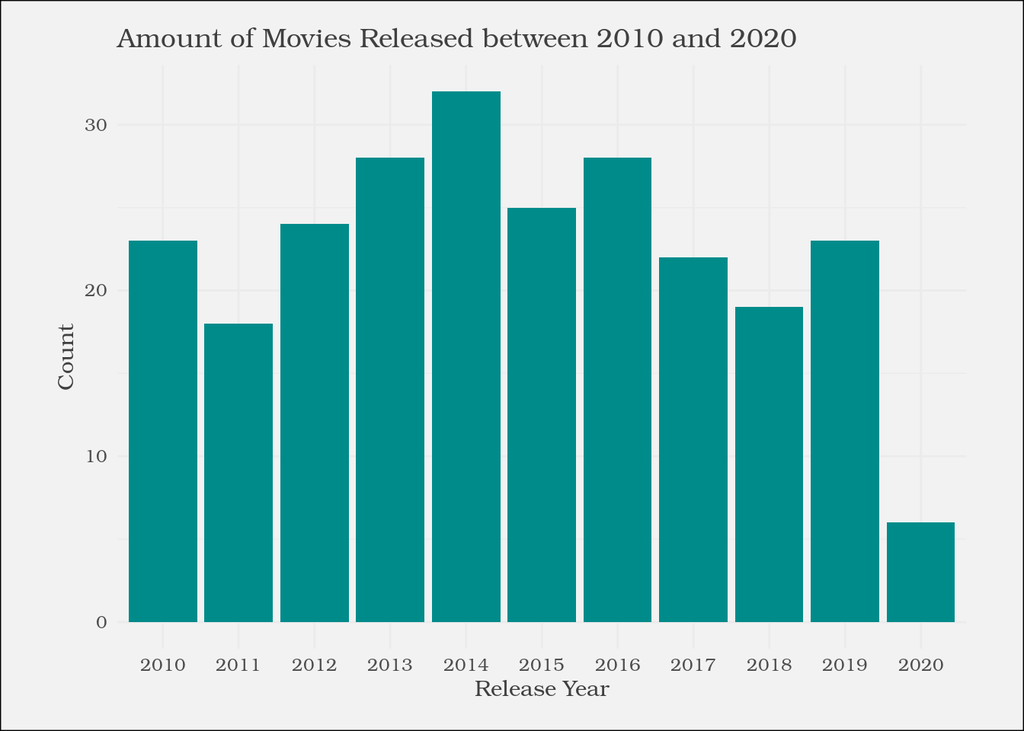

```r
# Make graph
a <- dbGetQuery(db, 'SELECT Release_Year FROM movie_info
                WHERE Release_Year >= 2010 AND Release_Year <= 2020')

ggplot(a, aes(x = Release_Year)) +
  geom_bar(fill = "darkcyan") +
  cool_theme() +
  labs(title = "Amount of Movies Released between 2010 and 2020",
       x = "Release Year",
       y = "Count")
```

#### 3. What is the minimum, average and maximum ratings for “Action” movies.

#### Ensure that you query the genre using wild cards.

```r
# Minimum
dbGetQuery(db, 'SELECT MIN(IMDB_Rating) FROM movie_info
           WHERE Genre LIKE "%Action%"')
```

```
##   MIN(IMDB_Rating)
## 1              7.6
```

```r
# Average
dbGetQuery(db, 'SELECT AVG(IMDB_Rating) FROM movie_info
           WHERE Genre LIKE "%Action%"')
```

```
##   AVG(IMDB_Rating)
## 1         7.948677
```

```r
# Maximum
dbGetQuery(db, 'SELECT MAX(IMDB_Rating) FROM movie_info
           WHERE Genre LIKE "%Action%"')
```

```
##   MAX(IMDB_Rating)
## 1                9
```

The minimum rating for Action movies is 7.6. The average rating for Action movies is ~7.9. The maximum rating for Action movies is 9.

#### 4. What are the 25 highest-grossing movies within the dataset? Display the title, genre and gross.

```r
# Top 25
knitr::kable(dbGetQuery(db, 'SELECT Series_Title, Genre, Gross FROM movie_info
           WHERE NOT Gross = "NA" ORDER BY Gross DESC LIMIT 25'))
```

| Series_Title | Genre | Gross |
| --- | --- | --- |
| Star Wars: Episode VII - The Force Awakens | Action, Adventure, Sci-Fi | 936662225 |
| Avengers: Endgame | Action, Adventure, Drama | 858373000 |
| Avatar | Action, Adventure, Fantasy | 760507625 |
| Avengers: Infinity War | Action, Adventure, Sci-Fi | 678815482 |
| Titanic | Drama, Romance | 659325379 |
| The Avengers | Action, Adventure, Sci-Fi | 623279547 |
| Incredibles 2 | Animation, Action, Adventure | 608581744 |
| The Dark Knight | Action, Crime, Drama | 534858444 |
| Rogue One | Action, Adventure, Sci-Fi | 532177324 |
| The Dark Knight Rises | Action, Adventure | 448139099 |
| E.T. the Extra-Terrestrial | Family, Sci-Fi | 435110554 |
| Toy Story 4 | Animation, Adventure, Comedy | 434038008 |
| The Lion King | Animation, Adventure, Drama | 422783777 |
| Toy Story 3 | Animation, Adventure, Comedy | 415004880 |
| Captain America: Civil War | Action, Adventure, Sci-Fi | 408084349 |
| Jurassic Park | Action, Adventure, Sci-Fi | 402453882 |
| Guardians of the Galaxy Vol. 2 | Action, Adventure, Comedy | 389813101 |
| Harry Potter and the Deathly Hallows: Part 2 | Adventure, Drama, Fantasy | 381011219 |
| Finding Nemo | Animation, Adventure, Comedy | 380843261 |
| The Lord of the Rings: The Return of the King | Action, Adventure, Drama | 377845905 |
| Deadpool | Action, Adventure, Comedy | 363070709 |
| Inside Out | Animation, Adventure, Comedy | 356461711 |
| The Lord of the Rings: The Two Towers | Action, Adventure, Drama | 342551365 |
| Zootopia | Animation, Adventure, Comedy | 341268248 |
| Joker | Crime, Drama, Thriller | 335451311 |

#### 5. Which directors have the highest-grossing movies. Display the director name and the total gross.

#### Ensure that you join the necessary tables. Visualize the results using a Bar chart.

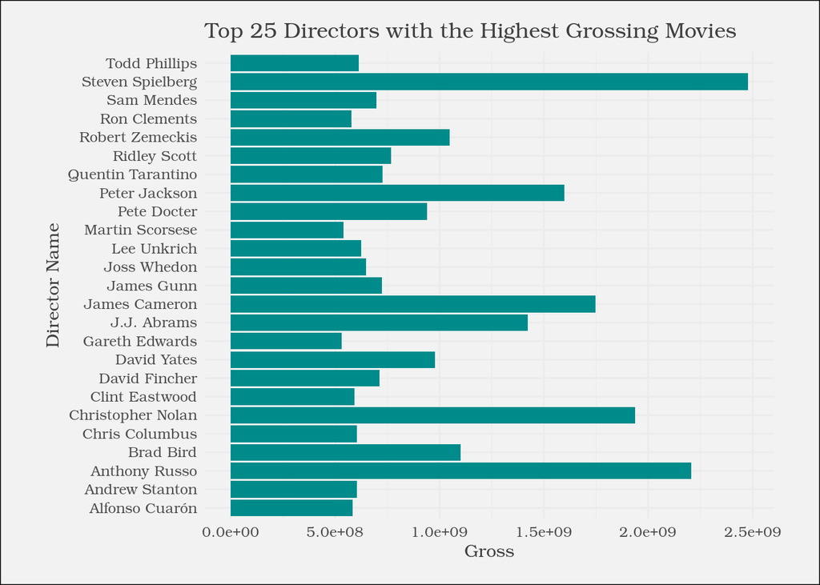

```r
# Join tables and get highest gross per Director
z <- dbGetQuery(db, 'SELECT director_info.Director_Name, movie_info.Gross
           FROM movie_info INNER JOIN director_info
           ON movie_info.Director_ID=director_info.Director_ID
           WHERE NOT Gross = "NA" ORDER BY Gross DESC')

z2 <- aggregate(. ~ Director_Name, z, sum, na.rm = TRUE)

z2 %>%
  arrange(desc(Gross)) %>%
  top_n(25, Gross) %>%
  ggplot(aes(x = Director_Name, y = Gross)) +
  geom_bar(stat = "identity", fill = "darkcyan") +
  coord_flip() +
  cool_theme() +
  labs(title = "Top 25 Directors with the Highest Grossing Movies",
       x = "Director Name")
```

The director with the highest cumulative grossing movies is Steven Spielberg, with a total gross of nearly 2,500,000,000.

#### 6. Create a function called `verifyDirector()` that takes a director name as its argument, and

#### queries the database to check if the director exists. Your function should display a message to notify

#### the user if the director was found or not.

```r
# Create function
verifyDirector <- function(name) {
  sqlCmd = 'SELECT * FROM director_info WHERE Director_Name = :x'
  query <- dbSendQuery(db, sqlCmd)
  dbBind(query, params = list(x = name))
  rs <- dbFetch(query)
  s <- if (nrow(rs) < 1) {
    print("Director not found")
  } else {
    print("Director found")
    print(rs)
  }
  dbClearResult(query)
}

# Test function
verifyDirector("Brad Bird")
```

```
## [1] "Director found"
##   Director_ID Director_Name
## 1          59     Brad Bird
```